# Module 12 Lab

#### Part 2: Tuning a Regularized Classification Model

Your objective is to tune a regularized logistic regression model to find the hyperparameter values that maximize the AUC model metric. Using the code chunk below, fill in the blanks to:

1. Split the data into a training set and test set using a 70-30% split. Be sure to include the set.seed(123) so that your train and test sets are the same size as mine.
2. Create a recipe that will model type as a function of all predictor variables. Apply the following feature engineering steps in this order:
   1. Normalize all numeric predictor variables using a Yeo-Johnson transformation
   2. Standardize all numeric predictor variables
3. Create a 5-fold cross validation resampling object.
4. Create a regularized logistic regression model object that:
   1. Contains tuning placeholders for the mixture and penalty arguments
   2. Sets the engine to use the glmnet package.
   3. Sets the mode to be a classification model.
5. Create our hyperparameter search grid that:
   1. Searches across default values for mixture
   2. Searches across values ranging from -10 to 5 for penalty
   3. Will search across 10 values for each of these hyperparameters (levels)
6. Creates a workflow object that combines our recipe object with our model object.
7. Performs a hyperparameter search.
8. Assesses the results.

```r
# install.packages("kernlab") if you don't have this package installed
library(kernlab)
data(spam)

# Splitting the data
set.seed(123)
split <- initial_split(data = spam, prop = 0.7, strata = type)
spam_train <- training(split)
spam_test <- testing(split)

# Spam recipe
spam_recipe <- recipe(type ~ ., data = spam_train) %>%
  step_YeoJohnson(all_numeric_predictors()) %>%
  step_normalize(all_numeric_predictors())

# Creating CV object
set.seed(123)
kfolds <- vfold_cv(data = spam_train, v = 5, strata = type)

# Creating regularized logistic regression model with tuning params
logit_mod <- logistic_reg(mode = "classification",
                          penalty = tune(),
                          mixture = tune(),
                          engine = "glmnet")

# Hyperparameter grid search for penalty and mixture
logit_grid <- grid_regular( mixture(),
                           penalty(range = c(-10, 5)),
                           levels = 10)

# Create workflow and tune the parameters
spam_wf <- workflow() %>%
  add_recipe(spam_recipe) %>%
  add_model(logit_mod)

tuning_results <- spam_wf %>%
  tune_grid(resamples = kfolds, grid = logit_grid)
```

Now, fill in the blanks below to:

1. finalize our workflow object with the optimal hyperparameter values,
2. fit our final workflow object across the full training set data, and
3. plot the top 10 most influential features.

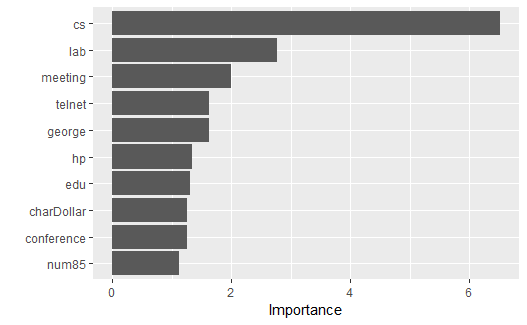

```r
# Step 1. finalize our workflow object with the optimal hyperparameter values
best_hyperparameters <- select_best(tuning_results, metric = "roc_auc")

final_wf <- workflow() %>%
add_recipe(spam_recipe) %>%
add_model(logit_mod) %>%
finalize_workflow(best_hyperparameters)

# Step 2. fit our final workflow object across the full training set data
final_fit <- final_wf %>%
fit(data = spam_train)

# Step 3. plot the top 10 most influential features
final_fit %>%
extract_fit_parsnip() %>%
vip()
```

#### Part 3: Tuning a MARS Model

For this part of the lab we’ll continue using the kernlab::spam data set. Your objective is to tune a MARS classification model to find the hyperparameter values that maximize the AUC model metric. Using the code chunk below, fill in the blanks to:

1. Split the data into a training set and test set using a 70-30% split. Be sure to include the set.seed(123) so that your train and test sets are the same size as mine.
2. Create a recipe that will model type as a function of all predictor variables. Apply the following feature engineering steps in this order:
   1. Normalize all numeric predictor variables using a Yeo-Johnson transformation
   2. Standardize all numeric predictor variables
3. Create a 5-fold cross validation resampling object.
4. Create a MARS model object that:
   1. Contains tuning placeholders for the num_terms and prod_degree arguments
   2. Sets the mode to be a classification model.
5. Create our hyperparameter search grid that:
   1. Searches across values ranging from 1 to 30 for num_terms
   2. Searches across default values for prod_degree
   3. Will search across 25 values for each of these hyperparameters (levels)
6. Creates a workflow object that combines our recipe object with our model object.
7. Performs a hyperparameter search.
8. Assesses the results.

```r
# Step 4: create ridge model object
mars_mod <- mars(num_terms = tune(), prod_degree = tune()) %>%
set_mode("classification")

# Step 5. create our hyperparameter search grid
mars_grid <- grid_regular(num_terms(range = c(1,30)), prod_degree(), levels = 25)

# Step 6: create workflow object to combine the recipe & model
spam_wf <- workflow() %>%
add_recipe(spam_recipe) %>%
add_model(mars_mod)

# Step 7. perform hyperparamter search
tuning_results <- spam_wf %>%
tune_grid(resamples = kfolds, grid = mars_grid)
```

```
! Fold3: preprocessor 1/1, model 2/2: glm.fit: algorithm did not converge, glm.fit: fitted probabilities numerically 0 or 1 occurre...
! Fold3: preprocessor 1/1, model 2/2 (predictions): glm.fit: algorithm did not converge, glm.fit: fitted probabilities numerically 0 or 1 occurre...
```

```r
# Step 8. assess results
tuning_results %>%
collect_metrics() %>%
filter(.metric == "roc_auc") %>%
arrange(desc(mean))
```

| num_terms | prod_degree | .metric | .estimator | mean | n | std_err | .config |
| --- | --- | --- | --- | --- | --- | --- | --- |
| 25 | 2 | roc_auc | binary | 0.9753323 | 5 | 0.003385629 | Preprocessor1_Model46 |
| 26 | 2 | roc_auc | binary | 0.9753323 | 5 | 0.003385629 | Preprocessor1_Model47 |
| 27 | 2 | roc_auc | binary | 0.9753323 | 5 | 0.003385629 | Preprocessor1_Model48 |
| 28 | 2 | roc_auc | binary | 0.9753323 | 5 | 0.003385629 | Preprocessor1_Model49 |
| 30 | 2 | roc_auc | binary | 0.9753323 | 5 | 0.003385629 | Preprocessor1_Model50 |
| 22 | 2 | roc_auc | binary | 0.9753302 | 5 | 0.003384304 | Preprocessor1_Model44 |
| 20 | 2 | roc_auc | binary | 0.9752995 | 5 | 0.003333388 | Preprocessor1_Model42 |
| 21 | 2 | roc_auc | binary | 0.9752810 | 5 | 0.003273698 | Preprocessor1_Model43 |
| 23 | 2 | roc_auc | binary | 0.9752796 | 5 | 0.003351397 | Preprocessor1_Model45 |
| 16 | 2 | roc_auc | binary | 0.9749765 | 5 | 0.003350320 | Preprocessor1_Model39 |

[output cut: 40 more lines]

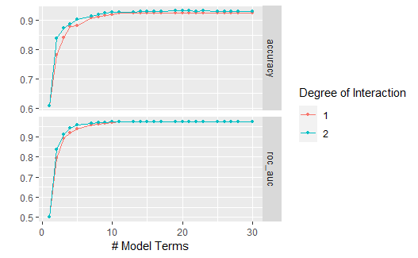

```r
autoplot(tuning_results)
```

Based on the graphs above, number of model terms (with a platuau around n=10) has a higher affect on roc_auc than the degree of interaction.

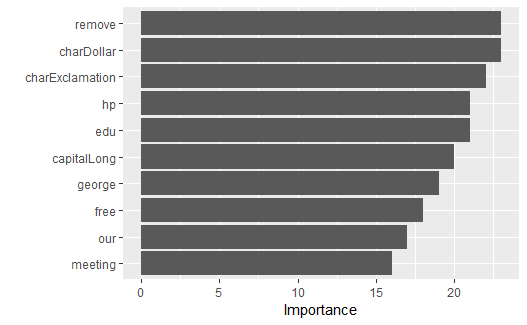

```r
# Step 1. finalize our workflow object with the optimal hyperparameter values
best_hyperparameters <- select_best(tuning_results, metric = "roc_auc")

final_wf <- workflow() %>%
add_recipe(spam_recipe) %>%
add_model(mars_mod) %>%
finalize_workflow(best_hyperparameters)

# Step 2. fit our final workflow object across the full training set data
final_fit <- final_wf %>%
fit(data = spam_train)

# Step 3. plot the top 10 most influential features
final_fit %>%
extract_fit_parsnip() %>%
vip()
```